# CLDN18 表达与结肠腺癌患者生存期的关联：基于 TCGA 数据库

liujingyi

2026-07-14

#研究介绍

##研究背景

结直肠癌（CRC）是全球范围内发病率与死亡率均位居前列的恶性肿瘤，对公众健康构成重大挑战。在II期结直肠癌患者中，CLDN18mRNA的高表达是一个独立的不良预后因素。因此，发掘能够精准预测预后、指导个体化治疗的新型生物标志物，是当前结直肠癌研究领域的重点和难点。 紧密连接蛋白（Claudins）是细胞间紧密连接的关键组分，在维持细胞极性和屏障功能中起核心作用。其中，CLDN18基因通过选择性剪接产生两种蛋白亚型（CLDN18.1和CLDN18.2）。近年研究发现，CLDN18在多种肿瘤中出现异常表达，并参与调控肿瘤的增殖、侵袭和转移。

##研究内容简介

#数据整理

##整理count数据

```r
####----------------------整理count数据----------------------####
rm(list = ls())
#设置工作目录
setwd("D:/gdc-client")
#加载R包
#install.packages("rjson")
library("rjson")
#读取metadata文件
json <- jsonlite::fromJSON("metadata.cart.2026-06-01.json")

#提取TCGA样本编号
#id <- json$associated_entities[[1]][,1]
sample_id <- sapply(json$associated_entities,function(x){x[,1]})
#将TCGA的样本编号和表达谱文件夹名称一一对应
file_sample <- data.frame(sample_id,file_name=json$file_name)

#获取cart文件夹下的所有TSV表达文件的 路径+文件名
count_file <- list.files('cart',pattern ='.tsv',recursive = T)
head(count_file)#查看数据结构
```

```
## [1] "00ae9ab8-6eaa-4085-af72-26f96df97fa3/90c9f8cd-4c8c-4f07-af2f-e17db69bd561.rna_seq.augmented_star_gene_counts.tsv"
## [2] "00cdff29-697a-4a17-ba67-cf55c006b827/0f35c851-1cb8-4f75-a661-eae9111b7362.rna_seq.augmented_star_gene_counts.tsv"
## [3] "01947597-c83a-4c5d-8a45-f1fe27992ad5/8ee55a63-4e87-4c00-8012-4c87efdcb7ed.rna_seq.augmented_star_gene_counts.tsv"
## [4] "0194feb1-d8be-45e5-9b95-0596090e9ecc/5c3c4b79-0682-4f19-96aa-071316a354d4.rna_seq.augmented_star_gene_counts.tsv"
## [5] "01d414a2-2b77-41e8-8622-98b277f5dc85/8a25dfb0-edd0-4a44-9a6b-8f3f761b940c.rna_seq.augmented_star_gene_counts.tsv"
## [6] "02033780-6bc1-407d-bd0f-45b6d74ae87b/c174e0ae-4b0a-4170-9122-b7da8ec61eac.rna_seq.augmented_star_gene_counts.tsv"
```

```r
#在count_file中分割出文件名
file_name <- strsplit(count_file,split='/')#以/为分隔符
file_name <- sapply(file_name,function(x){x[2]})#选择/后的数据
head(file_name)#查看数据结构，是否与file name一致
```

```
## [1] "90c9f8cd-4c8c-4f07-af2f-e17db69bd561.rna_seq.augmented_star_gene_counts.tsv"
## [2] "0f35c851-1cb8-4f75-a661-eae9111b7362.rna_seq.augmented_star_gene_counts.tsv"
## [3] "8ee55a63-4e87-4c00-8012-4c87efdcb7ed.rna_seq.augmented_star_gene_counts.tsv"
## [4] "5c3c4b79-0682-4f19-96aa-071316a354d4.rna_seq.augmented_star_gene_counts.tsv"
## [5] "8a25dfb0-edd0-4a44-9a6b-8f3f761b940c.rna_seq.augmented_star_gene_counts.tsv"
## [6] "c174e0ae-4b0a-4170-9122-b7da8ec61eac.rna_seq.augmented_star_gene_counts.tsv"
```

```r
#定义一个足够大的空矩阵
matrix <- data.frame(matrix(nrow=60660,ncol=0))
#提取每个样本的表达矩阵，counts数据的提取
for (i in 1:length(file_name)){
  path <- paste0('cart//',count_file[i])#读取工作路径
  data <- read.delim(path,fill = T,header = F,row.names = 1) #读取count.tsv文件
  colnames(data) <- data[2,]#第二行作为列名
  data <- data[-c(1:6),]#删除前6行
  data <- data[,3,drop=F]   #取出unstranded列（第3列），即count数据，对应其它数据可根据实际列号修改
  colnames(data) <- file_sample$sample_id[which(file_sample$file_name==file_name[i])]
  matrix <- cbind(matrix,data)
}
#保存表达矩阵
write.csv(matrix,'count_matrix.csv',row.names = T)

##设置Gene Symbol作为列名
#重新读取原始表达矩阵
path = paste0('cart//',count_file[1])
data <- as.matrix(read.delim(path,fill = T,header = F,row.names = 1))
#提取出第1列的gene_name（symbol）
gene_name <- data[-c(1:6),1]#删除前6行，提取第1列
#将gene_name（symbol）与上述未注释的基因表达谱合并
matrix0 <- cbind(gene_name,matrix)

#将gene_name列去除重复的基因，保留每个基因最大表达量结果
matrix0 <- aggregate( . ~ gene_name,data=matrix0, max)
#将gene_name列设为行名
rownames(matrix0) <- matrix0[,1]
#删除多余的第一列
matrix0 <- matrix0[,-1]
#保存最终整理好的counts数据
write.csv(matrix0,'counts-COAD.csv', row.names = T)
```

##整理临床数据

```r
####----------------------整理临床数据----------------------####
#rm(list = ls())
#设置工作目录
setwd("D:/gdc-client")
#此处读取metadata以及提取TCGA样本名
library(rjson)
json <- jsonlite::fromJSON("metadata.cart.2026-06-01.json")
entity_submitter_id <- sapply(json$associated_entities,function(x){x[,1]})
#提取case_id
case_id <- sapply(json$associated_entities,function(x){x[,3]})
#将TCGA样本名与病人编号合并后取转置
sample_case <- t(rbind(entity_submitter_id,case_id))
#读取clinical.tsv文件
clinical <- read.delim('clinical.tsv',header = T)
colnames(clinical)[2] <- "case_id"#将clinical里的第2列重命名为case_id
unique(clinical$cases.submitter_id)
```

[output not shown]

[output cut: 64 more lines]

```r
#识别并提取数据里存在重复的样本
clinical_unique <- clinical[!duplicated(clinical$case_id), ]

#clinical <- as.data.frame(clinical[duplicated(clinical$case_id),])
sum(duplicated(clinical$case_id))
```

```
## [1] 1157
```

```r
#根据“case_id”这一列将TCGA样本名整合进来
clinical_matrix <- merge(sample_case,clinical_unique,by="case_id",all.x=T)
#此时病人的编号已经没什么用了，将其删除
clinical_matrix <- clinical_matrix[,-1]
#colnames(clinical_unique)
#unique(clinical_unique$case_id) #查看几个case
#unique(clinical_unique$cases.submitter_id) #查看几个case
library(tidyverse)
```

```r
filter_clinical <- clinical_matrix %>% select("project.project_id","entity_submitter_id","demographic.age_at_index","demographic.gender",
                                       "demographic.vital_status","demographic.days_to_death","diagnoses.days_to_last_follow_up",
                                       "diagnoses.ajcc_pathologic_stage","diagnoses.ajcc_pathologic_t","diagnoses.ajcc_pathologic_m","diagnoses.ajcc_pathologic_n")
colnames(filter_clinical)#查看列名，便于复制
```

```
##  [1] "project.project_id"               "entity_submitter_id"
##  [3] "demographic.age_at_index"         "demographic.gender"
##  [5] "demographic.vital_status"         "demographic.days_to_death"
##  [7] "diagnoses.days_to_last_follow_up" "diagnoses.ajcc_pathologic_stage"
##  [9] "diagnoses.ajcc_pathologic_t"      "diagnoses.ajcc_pathologic_m"
## [11] "diagnoses.ajcc_pathologic_n"
```

```r
clinical_OS <- filter_clinical %>% rename(project=project.project_id,ID=entity_submitter_id,
                                          OS=demographic.vital_status,
                                          OS.time=diagnoses.days_to_last_follow_up,
                                          gender=demographic.gender,
                                          age=demographic.age_at_index,
                                          M=diagnoses.ajcc_pathologic_m,
                                          N=diagnoses.ajcc_pathologic_n,
                                          T=diagnoses.ajcc_pathologic_t,
                                          stage=diagnoses.ajcc_pathologic_stage,
)

#补齐OS.time
library(dplyr)
clinical_OS <- clinical_OS %>%
  mutate(
    OS.time = case_when(
      OS == "Dead" & is.na(OS.time) ~ demographic.days_to_death,
      TRUE ~ OS.time
    ),
    OS.time = as.numeric(OS.time)# 转为数值，便于生存分析
  )
clinical_OS$OS <- ifelse(str_detect(clinical_OS$OS,'Dead'),'1','0') #如果os列中为Dead是1, 其余是0
clinical_OS.time <- clinical_OS %>% select('ID', 'OS.time', 'OS',everything())#
view(clinical_OS.time)
#保存临床数据
write.csv(clinical,file = 'GDC_COAD_clinical.csv')
write.csv(clinical_OS.time,file = 'GDC_COAD_clinical_OS.time.csv')
save(matrix,matrix0,clinical,clinical_OS.time,file = 'GDC_COAD_data.rda')#保存为rda文件
```

##整理tpm数据

```r
####----------------------构建tpm矩阵----------------------####
#获取cart文件夹下的所有TSV表达文件的 路径+文件名
tpm_file <- list.files('cart',pattern ='.tsv',recursive = T)
head(tpm_file)#查看数据结构
```

```
## [1] "00ae9ab8-6eaa-4085-af72-26f96df97fa3/90c9f8cd-4c8c-4f07-af2f-e17db69bd561.rna_seq.augmented_star_gene_counts.tsv"
## [2] "00cdff29-697a-4a17-ba67-cf55c006b827/0f35c851-1cb8-4f75-a661-eae9111b7362.rna_seq.augmented_star_gene_counts.tsv"
## [3] "01947597-c83a-4c5d-8a45-f1fe27992ad5/8ee55a63-4e87-4c00-8012-4c87efdcb7ed.rna_seq.augmented_star_gene_counts.tsv"
## [4] "0194feb1-d8be-45e5-9b95-0596090e9ecc/5c3c4b79-0682-4f19-96aa-071316a354d4.rna_seq.augmented_star_gene_counts.tsv"
## [5] "01d414a2-2b77-41e8-8622-98b277f5dc85/8a25dfb0-edd0-4a44-9a6b-8f3f761b940c.rna_seq.augmented_star_gene_counts.tsv"
## [6] "02033780-6bc1-407d-bd0f-45b6d74ae87b/c174e0ae-4b0a-4170-9122-b7da8ec61eac.rna_seq.augmented_star_gene_counts.tsv"
```

```r
#在count_file中分割出文件名
file_name <- strsplit(tpm_file,split='/')#以/为分隔符
file_name <- sapply(file_name,function(x){x[2]})#选择/后的数据
head(file_name)#查看数据结构，是否与file name一致
```

```
## [1] "90c9f8cd-4c8c-4f07-af2f-e17db69bd561.rna_seq.augmented_star_gene_counts.tsv"
## [2] "0f35c851-1cb8-4f75-a661-eae9111b7362.rna_seq.augmented_star_gene_counts.tsv"
## [3] "8ee55a63-4e87-4c00-8012-4c87efdcb7ed.rna_seq.augmented_star_gene_counts.tsv"
## [4] "5c3c4b79-0682-4f19-96aa-071316a354d4.rna_seq.augmented_star_gene_counts.tsv"
## [5] "8a25dfb0-edd0-4a44-9a6b-8f3f761b940c.rna_seq.augmented_star_gene_counts.tsv"
## [6] "c174e0ae-4b0a-4170-9122-b7da8ec61eac.rna_seq.augmented_star_gene_counts.tsv"
```

```r
#定义一个足够大的空矩阵
matrix <- data.frame(matrix(nrow=60660,ncol=0))
#提取每个样本的表达矩阵，tpm数据的提取，用于生存分析
for (i in 1:length(file_name)){
  path <- paste0('cart//',tpm_file[i])#读取工作路径
  data <- read.delim(path,fill = T,header = F,row.names = 1) #读取count.tsv文件
  colnames(data) <- data[2,]#第二行作为列名
  data <- data[-c(1:6),]#删除前6行
  data <- data[,6,drop=F]   #tpm选择6
  colnames(data) <- file_sample$sample_id[which(file_sample$file_name==file_name[i])]
  matrix <- cbind(matrix,data)
}
matrix_tpm <- matrix
#保存表达矩阵
write.csv(matrix_tpm,'tpm_matrix.csv',row.names = T)

####----------------------ID与tpm合并----------------------####
##设置Gene Symbol作为列名
#重新读取原始表达矩阵
path = paste0('cart//',tpm_file[1])
data <- as.matrix(read.delim(path,fill = T,header = F,row.names = 1))
#提取出第1列的gene_name（symbol）
gene_name <- data[-c(1:6),1]#删除前6行，提取第1列
#将gene_name（symbol）与上述未注释的基因表达谱合并
matrix_tpm0 <- cbind(gene_name,matrix)
#将gene_name列去除重复的基因，保留每个基因最大表达量结果
matrix_tpm0 <- aggregate( . ~ gene_name,data=matrix_tpm0, max)
#将gene_name列设为行名
rownames(matrix_tpm0) <- matrix_tpm0[,1]
#删除多余的第一列
matrix_tpm0 <- matrix_tpm0[,-1]
matrix_tpm0 <- matrix_tpm0[,sample_id]
str(matrix_tpm0)#查看数据格式，是否为numeric
```

```
## 'data.frame':    59427 obs. of  411 variables:
##  $ TCGA-AZ-4616-01A-21R-1839-07: chr  "0.0000" "0.5871" "0.0000" "0.0000" ...
##  $ TCGA-AY-A71X-01A-12R-A37K-07: chr  "0.0000" "0.0000" "0.0000" "0.0401" ...
##  $ TCGA-AA-3861-01A-01R-1022-07: chr  "0.0000" "0.0000" "0.0000" "0.0000" ...
##  $ TCGA-AZ-6603-01A-11R-1839-07: chr  "0.0000" "1.1375" "0.0000" "0.0905" ...
##  $ TCGA-AA-A01C-01A-01R-A00A-07: chr  "0.0000" "0.0000" "0.0000" "0.1460" ...
##  $ TCGA-G4-6627-01A-11R-1774-07: chr  "0.0000" "0.0000" "0.0000" "0.0539" ...
##  $ TCGA-AZ-6599-01A-11R-1774-07: chr  "0.0000" "0.0000" "0.0000" "0.0199" ...
##  $ TCGA-F4-6809-01A-11R-1839-07: chr  "0.0000" "0.0000" "0.0000" "0.0144" ...
##  $ TCGA-5M-AAT6-01A-11R-A41B-07: chr  "0.0000" "1.8729" "0.6662" "0.0745" ...
##  $ TCGA-AA-A01D-01A-01R-A00A-07: chr  "0.0000" "0.0000" "0.0000" "0.0000" ...
##  $ TCGA-A6-6653-01A-11R-1774-07: chr  "0.0000" "0.0000" "0.0000" "0.0448" ...
##  $ TCGA-AZ-4684-01A-01R-1410-07: chr  "0.0000" "0.0000" "0.0000" "0.0000" ...
##  $ TCGA-D5-6534-01A-21R-1928-07: chr  "0.0000" "0.5664" "0.0000" "0.1351" ...
##  $ TCGA-DM-A1D8-01A-11R-A155-07: chr  "0.2609" "1.1222" "0.0000" "0.0198" ...
```

[output cut: 86 more lines]

```r
tpm_log2 <- log2(as.data.frame(lapply(matrix_tpm0, as.numeric)) + 1)
rownames(tpm_log2) <- rownames (matrix_tpm0)
colnames(tpm_log2) <- gsub('\\.','-',colnames(tpm_log2))
str(tpm_log2)
```

```
## 'data.frame':    59427 obs. of  411 variables:
##  $ TCGA-AZ-4616-01A-21R-1839-07: num  0 0.6664 0 0 0.0523 ...
##  $ TCGA-AY-A71X-01A-12R-A37K-07: num  0 0 0 0.0567 0.2121 ...
##  $ TCGA-AA-3861-01A-01R-1022-07: num  0 0 0 0 0.191 ...
##  $ TCGA-AZ-6603-01A-11R-1839-07: num  0 1.096 0 0.125 0.28 ...
##  $ TCGA-AA-A01C-01A-01R-A00A-07: num  0 0 0 0.197 0.23 ...
##  $ TCGA-G4-6627-01A-11R-1774-07: num  0 0 0 0.0757 0.2528 ...
##  $ TCGA-AZ-6599-01A-11R-1774-07: num  0 0 0 0.0284 0.0664 ...
##  $ TCGA-F4-6809-01A-11R-1839-07: num  0 0 0 0.0206 0.3686 ...
##  $ TCGA-5M-AAT6-01A-11R-A41B-07: num  0 1.523 0.737 0.104 0.585 ...
##  $ TCGA-AA-A01D-01A-01R-A00A-07: num  0 0 0 0 0.43 ...
##  $ TCGA-A6-6653-01A-11R-1774-07: num  0 0 0 0.0632 0.3091 ...
##  $ TCGA-AZ-4684-01A-01R-1410-07: num  0 0 0 0 0.256 ...
##  $ TCGA-D5-6534-01A-21R-1928-07: num  0 0.647 0 0.183 0.932 ...
##  $ TCGA-DM-A1D8-01A-11R-A155-07: num  0.3345 1.0856 0 0.0283 0.1141 ...
```

[output cut: 86 more lines]

```r
#保存最终整理好的tpm数据
write.csv(tpm_log2,'tpm-COAD.csv', row.names = T)
load('GDC_COAD_data.rda')
save(matrix,matrix0,clinical,clinical_OS.time,matrix_tpm,tpm_log2,file = 'GDC_COAD_count_tpm.rda')

####----------------------整理tpm.os数据----------------------####
#rm(list = ls())
load('GDC_COAD_data.rda')
load('GDC_COAD_count_tpm.rda')
str(tpm_log2)#查看数据格式，是否为numeric
```

```
## 'data.frame':    59427 obs. of  411 variables:
##  $ TCGA-AZ-4616-01A-21R-1839-07: num  0 0.6664 0 0 0.0523 ...
##  $ TCGA-AY-A71X-01A-12R-A37K-07: num  0 0 0 0.0567 0.2121 ...
##  $ TCGA-AA-3861-01A-01R-1022-07: num  0 0 0 0 0.191 ...
##  $ TCGA-AZ-6603-01A-11R-1839-07: num  0 1.096 0 0.125 0.28 ...
##  $ TCGA-AA-A01C-01A-01R-A00A-07: num  0 0 0 0.197 0.23 ...
##  $ TCGA-G4-6627-01A-11R-1774-07: num  0 0 0 0.0757 0.2528 ...
##  $ TCGA-AZ-6599-01A-11R-1774-07: num  0 0 0 0.0284 0.0664 ...
##  $ TCGA-F4-6809-01A-11R-1839-07: num  0 0 0 0.0206 0.3686 ...
##  $ TCGA-5M-AAT6-01A-11R-A41B-07: num  0 1.523 0.737 0.104 0.585 ...
##  $ TCGA-AA-A01D-01A-01R-A00A-07: num  0 0 0 0 0.43 ...
##  $ TCGA-A6-6653-01A-11R-1774-07: num  0 0 0 0.0632 0.3091 ...
##  $ TCGA-AZ-4684-01A-01R-1410-07: num  0 0 0 0 0.256 ...
##  $ TCGA-D5-6534-01A-21R-1928-07: num  0 0.647 0 0.183 0.932 ...
##  $ TCGA-DM-A1D8-01A-11R-A155-07: num  0.3345 1.0856 0 0.0283 0.1141 ...
```

[output cut: 86 more lines]

```r
tpm.os <- t(tpm_log2)#行列转置
tpm.os <- as.data.frame(tpm.os)#转化为数据框
library(tibble)
tpm.os <- rownames_to_column(.data = tpm.os,var = 'ID') #行名转为列, ID
tpm.os <- merge(tpm.os,clinical_OS.time,by ='ID')#两个数据框合并
library(tidyverse)
tpm.os <- select(.data = tpm.os,'ID','OS.time','OS',everything())#列名以'ID','os.time','os' 顺序
tpm.os <- arrange(tpm.os,OS)#对OS列进行排序
tpm.os$OS.time <-as.numeric(tpm.os$OS.time) /365 #天转化为年,转化为数字
tpm.os$os <-as.numeric(tpm.os$OS)#转化为数字格式
library(dplyr)
tpm.os <- tpm.os %>% filter(!is.na(OS.time))
write.csv(tpm.os,file ='GDC_COAD_tpm_os.csv')#csv保存
save(matrix,matrix0,clinical,clinical_OS.time,matrix_tpm,tpm_log2,tpm.os,file = 'GDC_COAD_data.rda')


####----------------------gene.os数据----------------------####
setwd('D:/gdc-client')#设置工作路径
load('GDC_COAD_data.rda')
library(survival)
library(survminer)
library(tidyverse)
gene <- 'CLDN18'
gene.os <- tpm.os
gene.os$group <- ifelse(gene.os$CLDN18 < median(gene.os$CLDN18),"low","high")
gene.os <- select(gene.os,group,OS,OS.time,CLDN18)
str(gene.os)
```

```
## 'data.frame':    336 obs. of  4 variables:
##  $ group  : chr  "low" "low" "low" "low" ...
##  $ OS     : chr  "0" "0" "0" "0" ...
##  $ OS.time: num  1.3 0.4 1.05 3.29 3.89 ...
##  $ CLDN18 : num  0.111 0.0896 0.1004 0.2423 0.116 ...
```

```r
gene.os$OS <- as.numeric(gene.os$OS)
str(gene.os$OS)
```

```
##  num [1:336] 0 0 0 0 0 0 0 0 0 0 ...
```

```r
#用 surv_cutpoint 找最佳截断值
library(survminer)
cutpoint <- surv_cutpoint(gene.os, time = "OS.time", event = "OS", variables = "CLDN18")
cutpoint
```

```
##         cutpoint statistic
## CLDN18 0.4001007   1.92172
```

```r
gene.os$group2 <- ifelse(gene.os$CLDN18 > cutpoint$cutpoint[1,"cutpoint"], "High", "Low")
```

#统计描述

```r
####----------------------统计描述----------------------####
library(dplyr)
library(tidyr)
library(survival)
library(survminer)
library(ggplot2)
#install.packages("table1")
library(table1)
library(tidyverse)
description <- 'CLDN18'
description.os <- tpm.os
description.os <- select(description.os,ID,OS,OS.time,CLDN18)
str(description.os)
```

```
## 'data.frame':    336 obs. of  4 variables:
##  $ ID     : chr  "TCGA-3L-AA1B-01A-11R-A37K-07" "TCGA-4N-A93T-01A-11R-A37K-07" "TCGA-4T-AA8H-01A-11R-A41B-07" "TCGA-5M-AATE-01A-11R-A41B-07" ...
##  $ OS     : chr  "0" "0" "0" "0" ...
##  $ OS.time: num  1.3 0.4 1.05 3.29 3.89 ...
##  $ CLDN18 : num  0.111 0.0896 0.1004 0.2423 0.116 ...
```

```r
description.os$OS <- as.numeric(description.os$OS)
str(description.os$OS)
```

```
##  num [1:336] 0 0 0 0 0 0 0 0 0 0 ...
```

```r
#用 surv_cutpoint 找最佳截断值
library(survminer)
cutpoint <- surv_cutpoint(gene.os, time = "OS.time", event = "OS", variables = "CLDN18")
cutpoint
```

```
##         cutpoint statistic
## CLDN18 0.4001007   1.92172
```

```r
description.os$group <- ifelse(description.os$CLDN18 > cutpoint$cutpoint[1,"cutpoint"], "High", "Low")
colnames(clinical_OS.time)
```

```
##  [1] "ID"                        "OS.time"
##  [3] "OS"                        "project"
##  [5] "age"                       "gender"
##  [7] "demographic.days_to_death" "stage"
##  [9] "T"                         "M"
## [11] "N"
```

```r
colnames(description.os)
```

```
## [1] "ID"      "OS"      "OS.time" "CLDN18"  "group"
```

```r
clinical_subset <- clinical_OS.time %>%
  select(ID, age, gender, stage, T, M, N)# 从 clinical_OS.time 中只提取需要的列（ID 和六个临床变量）
description.os <- description.os %>%
  left_join(clinical_subset, by = "ID")# 按 ID 左连接（保留 tpm.os 中的所有行，匹配上 clinical_subset 的信息）
description.os <- description.os %>%
  mutate(age_group = ifelse(age < 60, "< 60", "≥ 60"))# 按60岁创建年龄分组
head(description.os)
```

```
##                             ID OS  OS.time     CLDN18 group age gender
## 1 TCGA-3L-AA1B-01A-11R-A37K-07  0 1.301370 0.11103131   Low  61 female
## 2 TCGA-4N-A93T-01A-11R-A37K-07  0 0.400000 0.08963374   Low  67   male
## 3 TCGA-4T-AA8H-01A-11R-A41B-07  0 1.054795 0.10043948   Low  42 female
## 4 TCGA-5M-AATE-01A-11R-A41B-07  0 3.287671 0.24232812   Low  76   male
## 5 TCGA-A6-2672-01A-01R-0826-07  0 3.887671 0.11596543   Low  82 female
## 6 TCGA-A6-2672-01B-03R-2302-07  0 3.887671 1.43151599  High  82 female
##        stage   T  M   N age_group
## 1    Stage I  T2 M0  N0      ≥ 60
## 2 Stage IIIB T4a M0 N1b      ≥ 60
## 3  Stage IIA  T3 MX  N0      < 60
## 4  Stage IIA  T3 M0  N0      ≥ 60
## 5 Stage IIIB  T3 M0  N1      ≥ 60
## 6 Stage IIIB  T3 M0  N1      ≥ 60
```

```r
colnames(description.os)# 检查合并后的数据
```

```
##  [1] "ID"        "OS"        "OS.time"   "CLDN18"    "group"     "age"
##  [7] "gender"    "stage"     "T"         "M"         "N"         "age_group"
```

```r
table(description.os$group)
```

```
##
## High  Low
##  121  215
```

```r
description.os <- description.os %>%
  mutate(
    stage = ifelse(stage == "'--" | stage == "", NA, stage),
    T = ifelse(T == "'--" | T == "", NA, T),
    M = ifelse(M == "'--" | M == "", NA, M),
    N = ifelse(N == "'--" | N == "", NA, N)
  )#stage、T、M、N 中有缺失值，需要先处理# 将 '--' 转为 NA
colSums(is.na(description.os[, c("age", "gender", "stage", "T", "M", "N","age_group")]))#查看缺失值
```

```
##       age    gender     stage         T         M         N age_group
##         0         0         9         0         5         0         0
```

```r
library(dplyr)
description.os <- description.os %>%
  filter(!is.na(stage) & !is.na(M))# 删除stage和T里面的缺失值
#stage分组
description.os <- description.os %>%
  mutate(
    stage_simple = case_when(
      # 先处理合并后的类别
      stage %in% c("Stage I", "Stage IA", "Stage IB",
                   "Stage II", "Stage IIA", "Stage IIB", "Stage IIC") ~ "Early",
      stage %in% c("Stage III", "Stage IIIA", "Stage IIIB", "Stage IIIC",
                   "Stage IV", "Stage IVA", "Stage IVB") ~ "Late",
    ),
    # 转为因子，并指定顺序
    stage_simple = factor(stage_simple, levels = c("Early", "Late"))
  )

# 检查合并后的分布
table(description.os$stage_simple, description.os$group)
```

```
##
##         High Low
##   Early   74 119
##   Late    41  90
```

```r
# 合并 T 分期（T1/T2 合并为早期T，T3/T4 合并为晚期T）
description.os <- description.os %>%
  mutate(
    T_simple = case_when(
      T %in% c("T1", "T2", "Tis") ~ "T1-T2",
      T %in% c("T3", "T4", "T4a", "T4b") ~ "T3-T4",
     ),
    # 合并 M 分期（M0、M1、MX）
    M_simple = case_when(
      M == "M0" ~ "M0",
      M %in% c("M1", "M1a", "M1b") ~ "M1",
      M == "MX" ~ "MX",
    ),
    # 合并 N 分期（N0、N1、N2）
    N_simple = case_when(
      N == "N0" ~ "N0",
      N %in% c("N1", "N1a", "N1b", "N1c") ~ "N1",
      N %in% c("N2", "N2a", "N2b") ~ "N2",
    ),
  )
# 转为因子
description.os$T_simple <- factor(description.os$T_simple, levels = c("T1-T2", "T3-T4"))
description.os$M_simple <- factor(description.os$M_simple, levels = c("M0", "M1", "MX"))
description.os$N_simple <- factor(description.os$N_simple, levels = c("N0", "N1", "N2"))
description.os$gender <- factor(description.os$gender, levels = c("female", "male"))# 把 gender 转为因子
colSums(is.na(description.os[, c("age", "gender", "stage", "T", "M", "N","age_group")]))#查看缺失值
```

```
##       age    gender     stage         T         M         N age_group
##         0         0         0         0         0         0         0
```

```r
table1(~ age_group + gender + stage_simple + T_simple + M_simple + N_simple | group, data = description.os)# 使用 table1 包制作按 group 分层的基线表
```

|  | High (N=115) | Low (N=209) | Overall (N=324) |
| --- | --- | --- | --- |
| age_group |  |  |  |
| < 60 | 30 (26.1%) | 60 (28.7%) | 90 (27.8%) |
| ≥ 60 | 85 (73.9%) | 149 (71.3%) | 234 (72.2%) |
| gender |  |  |  |
| female | 51 (44.3%) | 97 (46.4%) | 148 (45.7%) |
| male | 64 (55.7%) | 112 (53.6%) | 176 (54.3%) |
| stage_simple |  |  |  |
| Early | 74 (64.3%) | 119 (56.9%) | 193 (59.6%) |
| Late | 41 (35.7%) | 90 (43.1%) | 131 (40.4%) |
| T_simple |  |  |  |
| T1-T2 | 24 (20.9%) | 41 (19.6%) | 65 (20.1%) |
| T3-T4 | 91 (79.1%) | 168 (80.4%) | 259 (79.9%) |
| M_simple |  |  |  |
| M0 | 91 (79.1%) | 148 (70.8%) | 239 (73.8%) |
| M1 | 5 (4.3%) | 35 (16.7%) | 40 (12.3%) |
| MX | 19 (16.5%) | 26 (12.4%) | 45 (13.9%) |
| N_simple |  |  |  |
| N0 | 75 (65.2%) | 126 (60.3%) | 201 (62.0%) |
| N1 | 21 (18.3%) | 53 (25.4%) | 74 (22.8%) |
| N2 | 19 (16.5%) | 30 (14.4%) | 49 (15.1%) |

```r
#保存table1
#install.packages("flextable")
library(flextable)
```

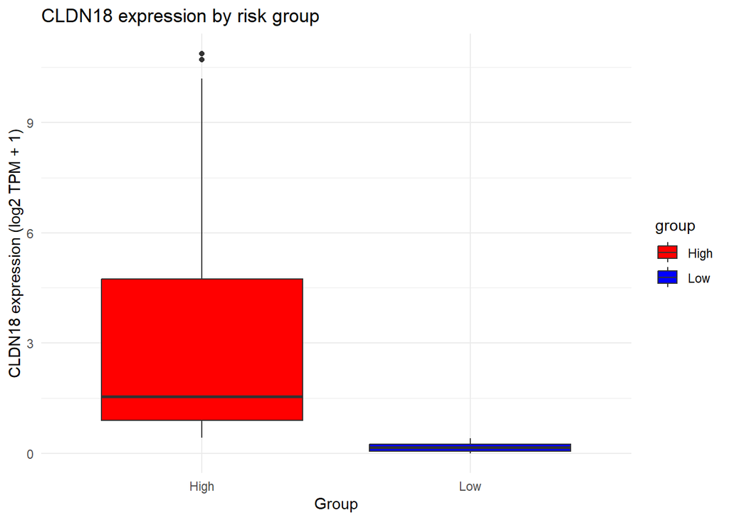

```r
tab1 <- table1(~ age_group + gender + stage_simple + T_simple + M_simple + N_simple | group, data = description.os)
tab1_df <- as.data.frame(tab1)# 把 table1 转为数据框
ft <- flextable(tab1_df)#创建 flextable 对象
# 美化表格
ft <- theme_vanilla(ft)      # 使用简洁主题
ft <- autofit(ft)            # 自动调整列宽
ft <- bold(ft, part = "header")  # 表头加粗
ft <- align(ft, align = "center", part = "all")  # 所有文字居中
#保存为 Word 文档
save_as_docx(ft, path = "Table1.docx")

#箱线图
boxplot_cl <- ggplot(description.os, aes(x = group, y = .data[["CLDN18"]], fill = group)) +
  geom_boxplot() +
  labs(
    title = "CLDN18 expression by risk group",
    x = "Group",
    y = "CLDN18 expression (log2 TPM + 1)"
  ) +
  theme_minimal() +
  scale_fill_manual(values = c("Low" = "blue", "High" = "red"))
print(boxplot_cl)
```

```r
# 保存箱线图
ggsave("CLDN18_boxplot.png", boxplot_cl, width = 6, height = 5)
```

##结果解读

#统计推断

```r
####----------------------统计推断----------------------####
# 1 年龄的 卡方检验（高表达组 vs 低表达组）
chisq.test(table(description.os$group, description.os$age_group))
```

```
##
##  Pearson's Chi-squared test with Yates' continuity correction
##
## data:  table(description.os$group, description.os$age_group)
## X-squared = 0.1402, df = 1, p-value = 0.7081
```

```r
# 2 性别的卡方检验
chisq.test(table(description.os$group, description.os$gender))
```

```
##
##  Pearson's Chi-squared test with Yates' continuity correction
##
## data:  table(description.os$group, description.os$gender)
## X-squared = 0.057732, df = 1, p-value = 0.8101
```

```r
# 3 分期的卡方检验
chisq.test(table(description.os$group, description.os$stage_simple))
```

```
##
##  Pearson's Chi-squared test with Yates' continuity correction
##
## data:  table(description.os$group, description.os$stage_simple)
## X-squared = 1.3975, df = 1, p-value = 0.2371
```

```r
# 4 T的卡方检验
chisq.test(table(description.os$group, description.os$T_simple))
```

```
##
##  Pearson's Chi-squared test with Yates' continuity correction
##
## data:  table(description.os$group, description.os$T_simple)
## X-squared = 0.015471, df = 1, p-value = 0.901
```

```r
#5 M的卡方检验
chisq.test(table(description.os$group, description.os$M_simple))
```

```
##
##  Pearson's Chi-squared test
##
## data:  table(description.os$group, description.os$M_simple)
## X-squared = 10.822, df = 2, p-value = 0.004466
```

```r
# 6 N的卡方检验
chisq.test(table(description.os$group, description.os$N_simple))
```

```
##
##  Pearson's Chi-squared test
##
## data:  table(description.os$group, description.os$N_simple)
## X-squared = 2.1575, df = 2, p-value = 0.34
```

##结果解读

本研究共纳入 324 例结肠腺癌患者，按 CLDN18 表达水平分为高表达组（115 例）和低表达组（209 例）。基线特征分析显示，两组在年龄（P = 0.708）、性别（P = 0.810）、临床分期（P = 0.237）、T 分期（P = 0.901）和 N 分期（P = 0.340）上的分布均无统计学差异，提示两组具有可比性。值得注意的是，M 分期在两组间存在显著差异（P = 0.004），低表达组中 M1（远处转移）的比例（16.7%）高于表达组（4.3%），说明CLDN18 低表达可能与肿瘤远处转移能力增强相关。

#KM生存曲线

```r
####----------------------绘制生存曲线----------------------####
?ggsurvplot
```

```
## starting httpd help server ... done
```

```
## Ignoring unknown labels:
## • colour : "CLDN18 exp"
```

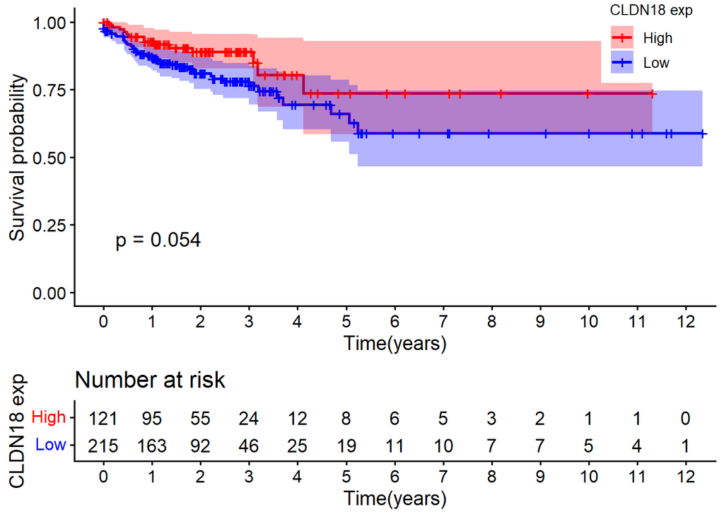

```r
fit <- survfit(Surv(OS.time,OS)~group2, data=gene.os)
KM <- ggsurvplot(fit,data = gene.os,
                 conf.int=T,#是否展示置信区间
                 pval=T,pval.size=5,#是否展示P值，及P值大小
                 legend.labs=c('High','Low'),#group命名
                 legend.title='CLDN18 exp',xlab='Time(years)',#图例及x轴名
                 legend=c(0.9,0.9),font.legend=10,#图例位置及大小
                 risk.table = T,#是否展示risk table
                 break.time.by=1,#按1年间隔展示
                 palette = c('red','blue'),#自定义颜色
                 surv.median.line = 'hv',#添加中位数参考线，h水平，v垂直，none不添加
                 risk.table.height=.3)#数值(在[0-1]中)，指定主生存图下所有表格的总体高度。
KM
```

```r
#pdf保存km曲线
pdf(file = 'KM2_CLDN18.pdf',width = 6,height = 6)
KM
```

```
## Ignoring unknown labels:
## • colour : "CLDN18 exp"
```

```r
dev.off()
```

##结果解读

生存曲线显示，高表达组与低表达组在随访期间的生存概率存在一定分离，但两组间差异未达到统计学显著性水平（log-rank检验，p = 0.054）。两组均未达到中位生存时间（>50% 患者存活至随访结束），说明整体预后较好。

#CLDN18单因素Cox回归

```r
####----------------------CLDN18单因素Cox回归----------------------####
library(survival)
library(survminer)
library(ggplot2)
library(data.table)
library(dplyr)
gene_cox <- gene.os[, c("OS.time", "OS", "CLDN18")]
gene_cox <- gene_cox[gene_cox$OS.time > 0, ]
nrow(gene_cox)
```

```
## [1] 323
```

```r
gene_cox <- as.data.frame(gene_cox)# 把 use_cox 转为数据框
cox_cldn18 <- coxph(Surv(OS.time, OS) ~ `CLDN18`, data = gene_cox)  # 如果列名是 "CLDN18"
# 查看结果
summary(cox_cldn18)
```

```
## Call:
## coxph(formula = Surv(OS.time, OS) ~ CLDN18, data = gene_cox)
##
##   n= 323, number of events= 54
##
##           coef exp(coef) se(coef)     z Pr(>|z|)
## CLDN18 0.02300   1.02327  0.05786 0.398    0.691
##
##        exp(coef) exp(-coef) lower .95 upper .95
## CLDN18     1.023     0.9773    0.9136     1.146
##
## Concordance= 0.526  (se = 0.04 )
## Likelihood ratio test= 0.15  on 1 df,   p=0.7
## Wald test            = 0.16  on 1 df,   p=0.7
## Score (logrank) test = 0.16  on 1 df,   p=0.7
```

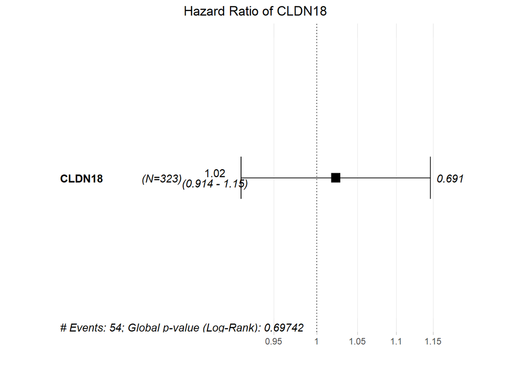

```r
# 加载森林图绘图包
library(survminer)
# 用 ggforest 直接画
forest_plot <- ggforest(cox_cldn18, data = gene_cox,
         main = "Hazard Ratio of CLDN18",
         cpositions = c(0.02, 0.22, 0.4),
         fontsize = 1,
         noDigits = 3)
forest_plot
```

```r
# 保存森林图
ggsave("CLDN18_forest_plot.png", plot = forest_plot, width = 10, height = 7, dpi = 300)
```

##结果解读

结果显示，CLDN18表达作为连续变量时，其风险比（ HR）为1.02，95%置信区间（95%CI）为0.914 ~ 1.15，p值为0.691。总体log-rank检验的全局p值为0.697。上述结果表明，CLDN18表达水平在本研究人群中未显示出对总生存期的显著独立预测作用。

#单因素Cox回归、Lasso-cox回归、多因素Cox回归

##单因素Cox回归

```r
####----------------------单因素Cox回归----------------------####
use_cox <- tpm.os
use_cox <- as.data.frame(use_cox)# 把 use_cox 转为数据框
td <- use_cox
outResult <- data.frame()
sigGenes <- c("surstat","surtime")
class(td$OS)
```

```
## [1] "character"
```

```r
td$OS <- as.numeric(td$OS)
library(data.table)
gene_name <- fread("gene_name.tsv", data.table = FALSE)
gene_name_subset <- gene_name[, 1:3]
gene_name_clean <- gene_name_subset[-c(1:4), ]
protein_coding_names <- gene_name_clean$gene_name[gene_name_clean$gene_type == "protein_coding"]# 提取 protein_coding 的基因名
keep_cols <- intersect(colnames(td), protein_coding_names)
td_protein <- td[, c("ID","OS.time", "OS", keep_cols)]# 只保留 td 里属于 protein_coding 的列
dim(td_protein)
```

```
## [1]   336 19941
```

```r
head(colnames(td_protein), 10)  # 查看前 10 个列名
```

```
##  [1] "ID"      "OS.time" "OS"      "A1BG"    "A1CF"    "A2M"     "A2ML1"
##  [8] "A3GALT2" "A4GALT"  "A4GNT"
```

```r
#基因列从第 4 列开始
expr_data <- td_protein[, 4:ncol(td_protein)]
# 计算每个基因在所有样本中的平均表达量（或中位数）
gene_means <- colMeans(expr_data, na.rm = TRUE)
# 只保留平均表达量 > 0.1 的基因
keep_genes <- names(gene_means[gene_means > 0.1])
td_filtered <- td_protein[, c("ID","OS.time", "OS", keep_genes)]
# 看看还剩多少
ncol(td_filtered) - 3
```

```
## [1] 16712
```

```r
grep("CLDN18", colnames(td_filtered), ignore.case = TRUE, value = TRUE)
```

```
## [1] "CLDN18"
```

```r
# 计算每个基因的方差
gene_vars <- apply(td_filtered[, 4:ncol(td_filtered)], 2, var, na.rm = TRUE)
# 只保留方差大于 75% 分位数的基因（即变异最大的前 25%）
threshold <- quantile(gene_vars, 0.75, na.rm = TRUE)
keep_genes <- names(gene_vars[gene_vars > threshold])
td_filtered <- td_filtered[, c("ID","OS.time", "OS", keep_genes)]
grep("CLDN18", colnames(td_filtered), ignore.case = TRUE, value = TRUE)
```

```
## [1] "CLDN18"
```

```r
ncol(td_filtered) - 3
```

```
## [1] 4178
```

```r
library(survival)
genes <- colnames(td_filtered)[4:ncol(td_filtered)]
p_values <- numeric(length(genes))

for (i in seq_along(genes)) {
  formula <- as.formula(paste0("Surv(OS.time, OS) ~ `", genes[i], "`"))
  cox_result <- tryCatch(
    coxph(formula, data = td_filtered),
    error = function(e) NULL
  )
  if (!is.null(cox_result)) {
    p_values[i] <- summary(cox_result)$coefficients[, "Pr(>|z|)"]
  } else {
    p_values[i] <- NA
  }
}

# 只保留 p < 0.05 的基因
keep_genes <- genes[!is.na(p_values) & p_values < 0.05]
td_filtered <- td_filtered[, c("ID","OS.time", "OS", keep_genes)]
grep("CLDN18", colnames(td_filtered), ignore.case = TRUE, value = TRUE)
```

```
## character(0)
```

```r
ncol(td_filtered) - 3
```

```
## [1] 419
```

```r
result_list <- lapply(colnames(td_filtered)[4:ncol(td_filtered)], function(i) {
  formula <- as.formula(paste0("Surv(OS.time, OS) ~ `", i, "`"))
  tdxcox <- coxph(formula, data = td_filtered)
  tdxcoxSummary <- summary(tdxcox)

  data.frame(
    id = i,
    HR = tdxcoxSummary$conf.int[, "exp(coef)"],
    L95CI = tdxcoxSummary$conf.int[, "lower .95"],
    H95CI = tdxcoxSummary$conf.int[, "upper .95"],
    pvalue = tdxcoxSummary$coefficients[, "Pr(>|z|)"]
  )
})

# 一次性合并所有结果
outResult <- do.call(rbind, result_list)
# 转成数值型
outResult$pvalue <- as.numeric(outResult$pvalue)
outResult$HR <- as.numeric(outResult$HR)
outResult$L95CI <- as.numeric(outResult$L95CI)
outResult$H95CI <- as.numeric(outResult$H95CI)

library(tibble)
library(dplyr)
outResult <- column_to_rownames(outResult,var = 'id')
outResult <- arrange(outResult,HR)
outResultt <- as.matrix(outResult)
colnames(outResult)
```

```
## [1] "HR"     "L95CI"  "H95CI"  "pvalue"
```

```r
HR <- outResult[,1:3] #注意第123列为 "HR""L95CI""H95CI"
#可视化作图
# ----- 1. 准备数据-----
# 按 HR 排序（从小到大）
plot_data <- outResult[order(outResult$HR), ]

# 提取数据
gene_names <- rownames(plot_data)
HR <- plot_data$HR
lower <- plot_data$L95CI
upper <- plot_data$H95CI
p_vals <- plot_data$pvalue

# ----- 2. 设置每页显示的基因数 -----
genes_per_page <- 30

# 计算总页数
total_genes <- nrow(plot_data)
n_pages <- ceiling(total_genes / genes_per_page)

# ----- 3. 循环分页画图并保存 -----
for (page in 1:n_pages) {

  # 计算当前页的起止行
  start_row <- (page - 1) * genes_per_page + 1
  end_row <- min(page * genes_per_page, total_genes)

  # 提取当前页的数据
  page_genes <- plot_data[start_row:end_row, ]
  page_names <- rownames(page_genes)
  page_HR <- page_genes$HR
  page_lower <- page_genes$L95CI
  page_upper <- page_genes$H95CI
  page_p <- page_genes$pvalue

  # 构建当前页的表格文字（表头 + 基因）
  tabletext <- cbind(
    c("Gene", page_names),
    c("HR (95% CI)", paste0(round(page_HR, 2), " (", round(page_lower, 2), "-", round(page_upper, 2), ")")),
    c("P value", round(page_p, 4))
  )

  # 打开 PDF 设备（每页一个 PDF）
  pdf(file = paste0("Forest_plot_page_", page, ".pdf"),
      width = 10, height = 8)
  # 加载森林图绘图包
  library(forestplot)
  # 画森林图
  p <- forestplot(
    labeltext = tabletext,
    mean = c(NA, page_HR),
    lower = c(NA, page_lower),
    upper = c(NA, page_upper),
    zero = 1,
    boxsize = 0.15,
    line.margin = 0.1,
    col = fpColors(box = "royalblue", line = "darkblue", zero = "red"),
    xlab = "Hazard Ratio (95% CI)",
    title = paste0("Univariate Cox Regression Forest Plot (Page ", page, "/", n_pages, ")")
  )

  p

  # 关闭 PDF 设备
  dev.off()

  cat("已保存第", page, "/", n_pages, "页，包含", nrow(page_genes), "个基因\n")
}
```

```
## 已保存第 1 / 14 页，包含 30 个基因
```

```
## 已保存第 2 / 14 页，包含 30 个基因
```

```
## 已保存第 3 / 14 页，包含 30 个基因
```

```
## 已保存第 4 / 14 页，包含 30 个基因
```

```
## 已保存第 5 / 14 页，包含 30 个基因
```

```
## 已保存第 6 / 14 页，包含 30 个基因
```

```
## 已保存第 7 / 14 页，包含 30 个基因
```

```
## 已保存第 8 / 14 页，包含 30 个基因
```

```
## 已保存第 9 / 14 页，包含 30 个基因
```

```
## 已保存第 10 / 14 页，包含 30 个基因
```

```
## 已保存第 11 / 14 页，包含 30 个基因
```

```
## 已保存第 12 / 14 页，包含 30 个基因
```

```
## 已保存第 13 / 14 页，包含 30 个基因
```

```
## 已保存第 14 / 14 页，包含 29 个基因
```

```r
cat("所有森林图已保存！共", n_pages, "个 PDF 文件。\n")
```

```
## 所有森林图已保存！共 14 个 PDF 文件。
```

###结果解读

##Lasso-cox降维

```r
####----------------------Lasso-cox降维----------------------####
#install.packages("glmnet")
library(glmnet)
#设置随机种子
set.seed(123)
dat<-td_filtered
str(dat)
```

```
## 'data.frame':    336 obs. of  422 variables:
##  $ ID        : chr  "TCGA-3L-AA1B-01A-11R-A37K-07" "TCGA-4N-A93T-01A-11R-A37K-07" "TCGA-4T-AA8H-01A-11R-A41B-07" "TCGA-5M-AATE-01A-11R-A41B-07" ...
##  $ OS.time   : num  1.3 0.4 1.05 3.29 3.89 ...
##  $ OS        : num  0 0 0 0 0 0 0 0 0 0 ...
##  $ ABCA3     : num  2.25 2.38 2.15 2.86 4.15 ...
##  $ ABCC4     : num  3.98 1.88 1.66 4.53 1.91 ...
##  $ ABCD1     : num  4.7 3.88 3.52 4.36 4.79 ...
##  $ ACADM     : num  4.45 3.15 4.71 4.43 4.93 ...
##  $ ACTC1     : num  0.4053 0.037 0.1596 0.0599 0.1837 ...
##  $ ADAM8     : num  3.1 2.97 2.42 3.2 5.4 ...
##  $ ADAP1     : num  5.03 6.15 5.09 5.68 5.95 ...
##  $ ADCK5     : num  5.46 5.38 5.19 4.73 4.9 ...
##  $ AGPAT2    : num  8.06 9.04 8.11 7.39 8.5 ...
##  $ AGRN      : num  5.66 5.34 5.12 5.47 7.28 ...
##  $ AIP       : num  6.6 6.67 5.79 6.4 7.27 ...
```

[output cut: 86 more lines]

```r
sum(dat$OS.time <= 0)
```

```
## [1] 13
```

```r
dat <- dat[dat$OS.time > 0, ]
#构建Lasso回归模型x，y
x <- as.matrix(dat[,c(4:ncol(dat))])
y <- Surv(dat$OS.time,dat$OS)
fit <- glmnet(x, y, family = "cox", nfolds = 10, lambda.min.ratio = 0.01)
#c-index
cvfit <- cv.glmnet(x,y,family='cox',type.measure = 'C',nfolds = 10)
```

```r
pdf(file = 'lasso.c-index.pdf',width = 6,height = 6)
plot(cvfit)
abline(v=log(c(cvfit$lambda.min, cvfit$lambda.1se)),lty='dashed')
dev.off()
```

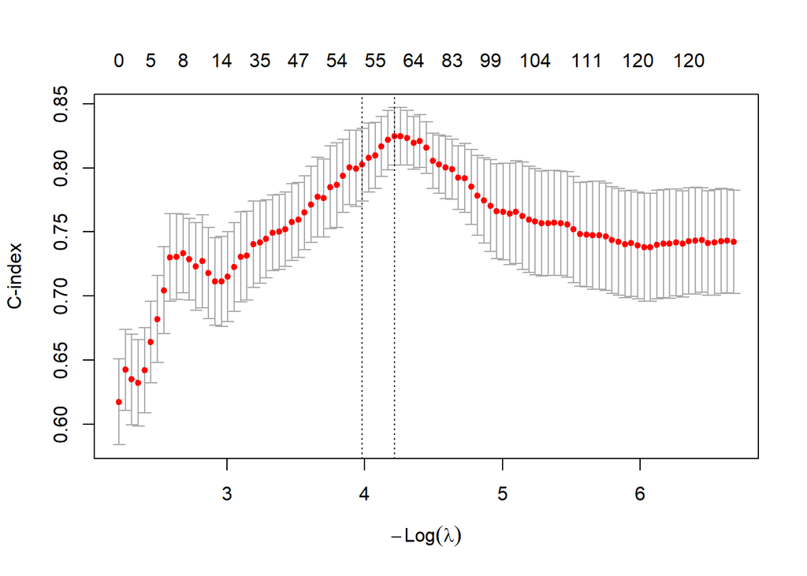

```r
plot(cvfit)
```

```r
#deviance
cvfit <- cv.glmnet(x,y,family='cox',type.measure = 'deviance',nfolds=10)
```

```r
pdf(file = 'lasso.cvfit.pdf',width = 6,height = 6)
plot(cvfit)
abline(v=log(c(cvfit$lambda.min,cvfit$lambda.1se)),lty='dashed')
dev.off()
```

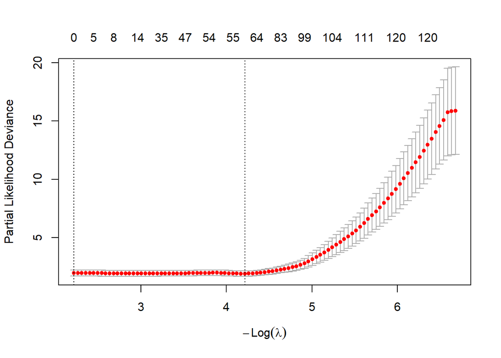

```r
plot(cvfit)
```

```r
#coefficients
pdf(file = 'lasso.lambda.pdf',width = 6,height = 6)
plot(fit,xvar = 'lambda',label = T)
abline(v=log (c(cvfit$lambda.min)),lty='dashed')
dev.off()
```

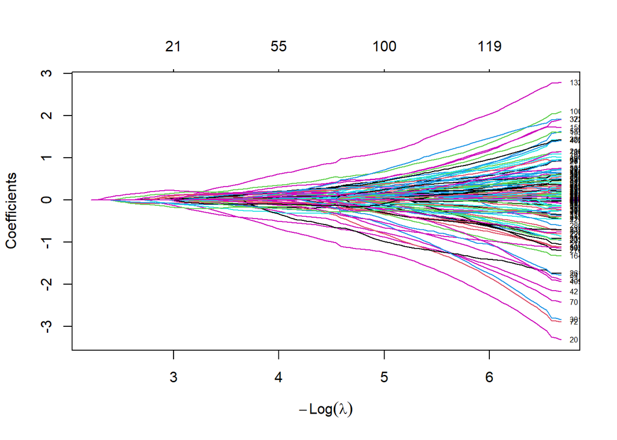

```r
plot(fit,xvar = 'lambda',label = T)
```

```r
#输出lasso结果
coef <- coef(fit,s=cvfit$lambda.min)
index <- which(coef!=0)
actcoef <- coef[index]
lassogenes <- row.names(coef)[index]
lassogenes
```

```
##  [1] "ABCC4"    "ALDH1A1"  "APOH"     "BOK"      "CALB1"    "CCL22"
##  [7] "CCNO"     "CELF2"    "CHGB"     "CRIP2"    "CTLA4"    "CTXN1"
## [13] "DIO2"     "EGFL7"    "EPHB6"    "ERFE"     "FAM24B"   "GDF15"
## [19] "GPRC5B"   "GPX3"     "H2BC13"   "HBA2"     "HOXC6"    "HOXD4"
## [25] "HOXD8"    "HSPA1A"   "HSPB1"    "IDUA"     "IGSF9"    "IRX3"
## [31] "ISG20"    "LGALS9B"  "LRRC32"   "MMP10"    "NKX6-3"   "NPM3"
## [37] "NSMF"     "PAX5"     "PCED1A"   "PCOLCE2"  "PDLIM7"   "PGF"
## [43] "PLCH2"    "PLXNB3"   "PNMA5"    "PPARGC1A" "RBP7"     "RORC"
## [49] "SERPINI1" "SFTA2"    "SLC29A4"  "SLC30A2"  "SYN1"     "TDGF1"
## [55] "TMEM139"  "TMEM184A" "TNFRSF19" "TPPP"     "WNT5A"    "ZBTB7C"
## [61] "ZDHHC11B"
```

```r
genecoef <- cbind(Gene=lassogenes,Coef=actcoef)
exp3 <- select(dat,c(1:3,lassogenes))
write.csv(exp3,file = 'lasso.tpm.csv')
```

###结果解读

##多因素Cox回归

```r
####----------------------多因素Cox回归----------------------####
setwd('D:/gdc-client')#设置工作路径
library(survival)
library(survminer)
library(tidyverse)
#数据导入
det <- read.csv(file = 'lasso.tpm.csv',header = T,row.names =1)
rownames(det) <- NULL
det <- column_to_rownames(det,var = 'ID')
#多因素cox
multicox <- coxph(Surv(OS.time,OS)~.,data = det)
multicoxSum <- summary(multicox)
multicoxSum
```

```
## Call:
## coxph(formula = Surv(OS.time, OS) ~ ., data = det)
##
##   n= 323, number of events= 54
##
##                coef  exp(coef)   se(coef)      z Pr(>|z|)
## ABCC4     -0.829826   0.436125   0.430328 -1.928 0.053811 .
## ALDH1A1    0.302437   1.353152   0.375169  0.806 0.420165
## APOH      -6.204383   0.002021   1.222846 -5.074 3.90e-07 ***
## BOK        1.744511   5.723100   0.894209  1.951 0.051069 .
## CALB1      1.192483   3.295253   0.324245  3.678 0.000235 ***
## CCL22     -0.211543   0.809334   0.823371 -0.257 0.797238
## CCNO      -0.598456   0.549660   0.590673 -1.013 0.310975
## CELF2      1.245642   3.475164   0.621692  2.004 0.045110 *
## CHGB       1.023992   2.784287   0.541178  1.892 0.058470 .
## CRIP2      1.916905   6.799879   0.901524  2.126 0.033479 *
## CTLA4     -5.514717   0.004027   1.378795 -4.000 6.34e-05 ***
## CTXN1     -1.152479   0.315853   0.516860 -2.230 0.025763 *
## DIO2      -2.985107   0.050534   0.920768 -3.242 0.001187 **
## EGFL7     -2.401879   0.090548   0.916560 -2.621 0.008779 **
## EPHB6     -0.628770   0.533247   0.621023 -1.012 0.311311
## ERFE       3.612010  37.040436   0.956751  3.775 0.000160 ***
## FAM24B     0.888211   2.430776   0.510837  1.739 0.082081 .
## GDF15     -1.088313   0.336784   0.467695 -2.327 0.019967 *
## GPRC5B     4.073494  58.761934   1.223838  3.328 0.000873 ***
## GPX3       0.387855   1.473816   0.479149  0.809 0.418247
## H2BC13    -5.104345   0.006070   1.338696 -3.813 0.000137 ***
## HBA2       0.585032   1.795048   0.258810  2.260 0.023792 *
## HOXC6      1.838419   6.286591   0.625389  2.940 0.003286 **
## HOXD4     -1.654286   0.191229   1.044646 -1.584 0.113288
## HOXD8      2.833312  17.001674   0.989628  2.863 0.004196 **
## HSPA1A     0.862937   2.370112   0.331294  2.605 0.009194 **
## HSPB1     -1.558073   0.210541   0.725694 -2.147 0.031792 *
## IDUA       4.833073 125.596353   1.138445  4.245 2.18e-05 ***
## IGSF9      3.517509  33.700368   0.904984  3.887 0.000102 ***
## IRX3       1.776827   5.911070   0.594910  2.987 0.002820 **
## ISG20      0.949097   2.583375   0.672451  1.411 0.158127
## LGALS9B    0.119958   1.127450   0.501793  0.239 0.811060
## LRRC32     2.645869  14.095683   1.154658  2.291 0.021936 *
## MMP10     -1.661366   0.189879   0.558428 -2.975 0.002929 **
```

[output cut: 82 more lines]

```
## SLC30A2  3.057e-01  3.271e+00 1.214e-01 7.697e-01
## SYN1     5.939e-01  1.684e+00 1.954e-01 1.805e+00
## TDGF1    7.970e-01  1.255e+00 3.378e-01 1.880e+00
## TMEM139  1.188e+01  8.417e-02 2.227e+00 6.338e+01
## TMEM184A 2.904e+00  3.444e-01 5.326e-01 1.583e+01
## TNFRSF19 4.922e-01  2.032e+00 2.405e-01 1.007e+00
## TPPP     2.942e-01  3.399e+00 1.003e-01 8.626e-01
## WNT5A    2.028e+00  4.932e-01 4.210e-01 9.765e+00
## ZBTB7C   4.517e-02  2.214e+01 1.036e-02 1.968e-01
## ZDHHC11B 2.027e+00  4.934e-01 5.829e-01 7.046e+00
##
## Concordance= 0.983  (se = 0.008 )
## Likelihood ratio test= 349.8  on 61 df,   p=<2e-16
## Wald test            = 69.58  on 61 df,   p=0.2
## Score (logrank) test = 361.4  on 61 df,   p=<2e-16
```

```r
#colnames(multicoxSum$conf.int)
multicoxres<-cbind(HR=multicoxSum$conf.int[,'exp(coef)'],
                   HR.95L=multicoxSum$conf.int[,'lower .95'],
                   HR.95H=multicoxSum$conf.int[,'upper .95'],
                   pvalue=multicoxSum$coefficients[,"Pr(>|z|)"])
view(multicoxres)
rownames(multicoxres)
```

```
##  [1] "ABCC4"    "ALDH1A1"  "APOH"     "BOK"      "CALB1"    "CCL22"
##  [7] "CCNO"     "CELF2"    "CHGB"     "CRIP2"    "CTLA4"    "CTXN1"
## [13] "DIO2"     "EGFL7"    "EPHB6"    "ERFE"     "FAM24B"   "GDF15"
## [19] "GPRC5B"   "GPX3"     "H2BC13"   "HBA2"     "HOXC6"    "HOXD4"
## [25] "HOXD8"    "HSPA1A"   "HSPB1"    "IDUA"     "IGSF9"    "IRX3"
## [31] "ISG20"    "LGALS9B"  "LRRC32"   "MMP10"    "NKX6.3"   "NPM3"
## [37] "NSMF"     "PAX5"     "PCED1A"   "PCOLCE2"  "PDLIM7"   "PGF"
## [43] "PLCH2"    "PLXNB3"   "PNMA5"    "PPARGC1A" "RBP7"     "RORC"
## [49] "SERPINI1" "SFTA2"    "SLC29A4"  "SLC30A2"  "SYN1"     "TDGF1"
## [55] "TMEM139"  "TMEM184A" "TNFRSF19" "TPPP"     "WNT5A"    "ZBTB7C"
## [61] "ZDHHC11B"
```

```r
write.csv(multicoxres,file ='多因素.csv',row.names = T)
rt <- read.csv('多因素.csv',header = T,row.names = 1)
diff <- rt %>% filter(pvalue < 0.05) %>% row.names()
diff
```

```
##  [1] "APOH"     "CALB1"    "CELF2"    "CRIP2"    "CTLA4"    "CTXN1"
##  [7] "DIO2"     "EGFL7"    "ERFE"     "GDF15"    "GPRC5B"   "H2BC13"
## [13] "HBA2"     "HOXC6"    "HOXD8"    "HSPA1A"   "HSPB1"    "IDUA"
## [19] "IGSF9"    "IRX3"     "LRRC32"   "MMP10"    "NPM3"     "PCOLCE2"
## [25] "PDLIM7"   "PGF"      "PLCH2"    "PLXNB3"   "PNMA5"    "SERPINI1"
## [31] "SFTA2"    "SLC30A2"  "TMEM139"  "TPPP"     "ZBTB7C"
```

```r
exp4 <- select(det,c(1:2,diff))
write.csv(exp4,file ='多因素tpm.csv',row.names = T)
#可视化作图
#多因素cox
colnames(det)
```

```
##  [1] "OS.time"  "OS"       "ABCC4"    "ALDH1A1"  "APOH"     "BOK"
##  [7] "CALB1"    "CCL22"    "CCNO"     "CELF2"    "CHGB"     "CRIP2"
## [13] "CTLA4"    "CTXN1"    "DIO2"     "EGFL7"    "EPHB6"    "ERFE"
## [19] "FAM24B"   "GDF15"    "GPRC5B"   "GPX3"     "H2BC13"   "HBA2"
## [25] "HOXC6"    "HOXD4"    "HOXD8"    "HSPA1A"   "HSPB1"    "IDUA"
## [31] "IGSF9"    "IRX3"     "ISG20"    "LGALS9B"  "LRRC32"   "MMP10"
## [37] "NKX6.3"   "NPM3"     "NSMF"     "PAX5"     "PCED1A"   "PCOLCE2"
## [43] "PDLIM7"   "PGF"      "PLCH2"    "PLXNB3"   "PNMA5"    "PPARGC1A"
## [49] "RBP7"     "RORC"     "SERPINI1" "SFTA2"    "SLC29A4"  "SLC30A2"
## [55] "SYN1"     "TDGF1"    "TMEM139"  "TMEM184A" "TNFRSF19" "TPPP"
## [61] "WNT5A"    "ZBTB7C"   "ZDHHC11B"
```

```r
library(survival)
library(forestplot)
# 确保数据没有 NA
det_clean <- det[complete.cases(det), ]
# 重新建模
multicox <- coxph(Surv(OS.time, OS) ~ ., data = det_clean, model = TRUE)
# 查看结果
summary(multicox)
```

```
## Call:
## coxph(formula = Surv(OS.time, OS) ~ ., data = det_clean, model = TRUE)
##
##   n= 323, number of events= 54
##
##                coef  exp(coef)   se(coef)      z Pr(>|z|)
## ABCC4     -0.829826   0.436125   0.430328 -1.928 0.053811 .
## ALDH1A1    0.302437   1.353152   0.375169  0.806 0.420165
## APOH      -6.204383   0.002021   1.222846 -5.074 3.90e-07 ***
## BOK        1.744511   5.723100   0.894209  1.951 0.051069 .
## CALB1      1.192483   3.295253   0.324245  3.678 0.000235 ***
## CCL22     -0.211543   0.809334   0.823371 -0.257 0.797238
## CCNO      -0.598456   0.549660   0.590673 -1.013 0.310975
## CELF2      1.245642   3.475164   0.621692  2.004 0.045110 *
## CHGB       1.023992   2.784287   0.541178  1.892 0.058470 .
## CRIP2      1.916905   6.799879   0.901524  2.126 0.033479 *
## CTLA4     -5.514717   0.004027   1.378795 -4.000 6.34e-05 ***
## CTXN1     -1.152479   0.315853   0.516860 -2.230 0.025763 *
## DIO2      -2.985107   0.050534   0.920768 -3.242 0.001187 **
## EGFL7     -2.401879   0.090548   0.916560 -2.621 0.008779 **
## EPHB6     -0.628770   0.533247   0.621023 -1.012 0.311311
## ERFE       3.612010  37.040436   0.956751  3.775 0.000160 ***
## FAM24B     0.888211   2.430776   0.510837  1.739 0.082081 .
## GDF15     -1.088313   0.336784   0.467695 -2.327 0.019967 *
## GPRC5B     4.073494  58.761934   1.223838  3.328 0.000873 ***
## GPX3       0.387855   1.473816   0.479149  0.809 0.418247
## H2BC13    -5.104345   0.006070   1.338696 -3.813 0.000137 ***
## HBA2       0.585032   1.795048   0.258810  2.260 0.023792 *
## HOXC6      1.838419   6.286591   0.625389  2.940 0.003286 **
## HOXD4     -1.654286   0.191229   1.044646 -1.584 0.113288
## HOXD8      2.833312  17.001674   0.989628  2.863 0.004196 **
## HSPA1A     0.862937   2.370112   0.331294  2.605 0.009194 **
## HSPB1     -1.558073   0.210541   0.725694 -2.147 0.031792 *
## IDUA       4.833073 125.596353   1.138445  4.245 2.18e-05 ***
## IGSF9      3.517509  33.700368   0.904984  3.887 0.000102 ***
## IRX3       1.776827   5.911070   0.594910  2.987 0.002820 **
## ISG20      0.949097   2.583375   0.672451  1.411 0.158127
## LGALS9B    0.119958   1.127450   0.501793  0.239 0.811060
## LRRC32     2.645869  14.095683   1.154658  2.291 0.021936 *
## MMP10     -1.661366   0.189879   0.558428 -2.975 0.002929 **
```

[output cut: 82 more lines]

```
## SLC30A2  3.057e-01  3.271e+00 1.214e-01 7.697e-01
## SYN1     5.939e-01  1.684e+00 1.954e-01 1.805e+00
## TDGF1    7.970e-01  1.255e+00 3.378e-01 1.880e+00
## TMEM139  1.188e+01  8.417e-02 2.227e+00 6.338e+01
## TMEM184A 2.904e+00  3.444e-01 5.326e-01 1.583e+01
## TNFRSF19 4.922e-01  2.032e+00 2.405e-01 1.007e+00
## TPPP     2.942e-01  3.399e+00 1.003e-01 8.626e-01
## WNT5A    2.028e+00  4.932e-01 4.210e-01 9.765e+00
## ZBTB7C   4.517e-02  2.214e+01 1.036e-02 1.968e-01
## ZDHHC11B 2.027e+00  4.934e-01 5.829e-01 7.046e+00
##
## Concordance= 0.983  (se = 0.008 )
## Likelihood ratio test= 349.8  on 61 df,   p=<2e-16
## Wald test            = 69.58  on 61 df,   p=0.2
## Score (logrank) test = 361.4  on 61 df,   p=<2e-16
```

[figure not shown]

```r
# 提取结果
cox_sum <- summary(multicox)
# 提取变量名
var_names <- rownames(cox_sum$coefficients)
# 提取 HR、CI、P 值
HR <- cox_sum$coefficients[, "exp(coef)"]
CI_lower <- cox_sum$conf.int[, "lower .95"]
CI_upper <- cox_sum$conf.int[, "upper .95"]
P_val <- cox_sum$coefficients[, "Pr(>|z|)"]
# 格式化文字
hr_text <- sprintf("%.2f", HR)
ci_text <- sprintf("%.2f (%.2f-%.2f)", HR, CI_lower, CI_upper)
p_text <- ifelse(P_val < 0.001, "<0.001", sprintf("%.3f", P_val))
# 构建表格 矩阵格式
tabletext <- cbind(
  c("Variable", var_names),
  c("HR (95% CI)", ci_text),
  c("P value", p_text)
)
# 画森林图（用 forestplot）
forestplot(
  labeltext = tabletext,
  mean = c(NA, HR),
  lower = c(NA, CI_lower),
  upper = c(NA, CI_upper),
  zero = 1,
  boxsize = 0.2,
  line.margin = 0.1,
  col = fpColors(box = "royalblue", line = "darkblue", zero = "red"),
  xlab = "Hazard Ratio (95% CI)",
  title = "Multivariate Cox Regression Forest Plot"
)
```

```r
# 保存为 PDF
pdf(file = "多-森林图.pdf", width = 10, height = max(6, length(var_names) * 0.4))
forestplot(
  labeltext = tabletext,
  mean = c(NA, HR),
  lower = c(NA, CI_lower),
  upper = c(NA, CI_upper),
  zero = 1,
  boxsize = 0.2,
  line.margin = 0.1,
  col = fpColors(box = "royalblue", line = "darkblue", zero = "red"),
  xlab = "Hazard Ratio (95% CI)",
  title = "Multivariate Cox Regression Forest Plot"
)
dev.off()
```

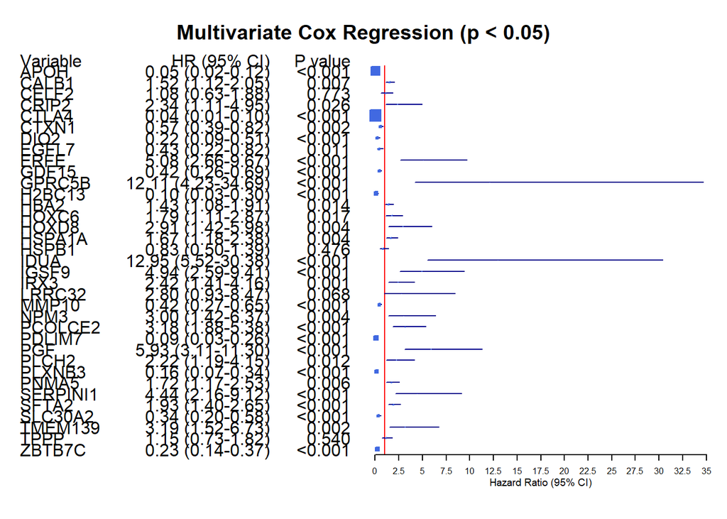

```r
setwd('D:/gdc-client')
library(survival)
library(forestplot)

# 1. 读取数据
exp4 <- read.csv('多因素tpm.csv', header = T, row.names = 1)

# 2. 建模
multicox <- coxph(Surv(OS.time, OS) ~ ., data = exp4)
sum_multicox <- summary(multicox)

# 3. 提取结果
var_names <- rownames(sum_multicox$coefficients)
HR <- sum_multicox$coefficients[, "exp(coef)"]
L95CI <- sum_multicox$conf.int[, "lower .95"]
H95CI <- sum_multicox$conf.int[, "upper .95"]
P_val <- sum_multicox$coefficients[, "Pr(>|z|)"]

# 4. 构建表格
tabletext <- cbind(
  c("Variable", var_names),
  c("HR (95% CI)", paste0(sprintf("%.2f", HR), " (", sprintf("%.2f", L95CI), "-", sprintf("%.2f", H95CI), ")")),
  c("P value", ifelse(P_val < 0.001, "<0.001", sprintf("%.3f", P_val)))
)

# 5. 画图
forestplot(
  labeltext = tabletext,
  mean = c(NA, HR),
  lower = c(NA, L95CI),
  upper = c(NA, H95CI),
  zero = 1,
  col = fpColors(box = "royalblue", line = "darkblue", zero = "red"),
  xlab = "Hazard Ratio (95% CI)",
  title = "Multivariate Cox Regression (p < 0.05)"
)
```

```r
pdf('多因素_显著基因_森林图.pdf', width = 10, height = 10)
forestplot(
  labeltext = tabletext,
  mean = c(NA, HR),
  lower = c(NA, L95CI),
  upper = c(NA, H95CI),
  zero = 1,
  col = fpColors(box = "royalblue", line = "darkblue", zero = "red"),
  xlab = "Hazard Ratio (95% CI)",
  title = "Multivariate Cox Regression (p < 0.05)"
)
dev.off()
```

###结果解读

#结论

1.研究共纳入324例患者，高表达组115例（35.5%），低表达组209例（64.5%）。两组在年龄、性别、分期、T分期及N分期上均无显著差异（P均>0.05），M分期分布差异有统计学意义（P=0.004），低表达组M1期比例（16.7%）高于高表达组（4.3%）。

3.生存分析结果显示，高表达组与低表达组间总生存期差异未达统计学显著性（log-rank P=0.054）。

4.单因素Cox回归分析进一步证实，CLDN18表达水平与患者总生存期无显著关联（HR=1.02，95% CI: 0.914~1.15，P=0.691）。

#讨论

1.LDN18表达与临床病理特征的关系

本研究发现，CLDN18高表达组与低表达组在年龄、性别、临床分期、T分期及N分期上均无显著差异（P均>0.05），但M分期在两组间分布差异具有统计学意义（P=0.004），低表达组M1期比例（16.7%）显著高于高表达组（4.3%），提示CLDN18低表达可能与远处转移倾向增加有关。 Chang等的研究通过IHC验证发现，Claudin 18蛋白在PNI阳性结直肠癌组织中的阳性表达率（56.8%）显著高于PNI阴性组织（33.3%，P=0.026），且其表达与年龄（P=0.014）和淋巴管侵犯（P=0.042）显著相关。该研究聚焦于II期CRC患者，发现CLDN18高表达与局部侵袭性特征（PNI、淋巴管侵犯）相关；而本研究发现CLDN18低表达与远处转移（M1期）相关。二者看似矛盾，实则可能揭示了CLDN18在肿瘤演进不同阶段的功能差异——在早期（II期）可能主要参与局部神经侵犯，而在晚期可能通过表达下调促进远处血行转移。此外，该研究还发现CLDN18表达与年龄相关，而本研究中两组年龄分布无显著差异（P=0.708），这一差异可能源于人群构成（II期 vs. 全分期）及检测平台（IHC蛋白 vs. RNA-seq转录组）的不同。

2.CLDN18与预后的关联

本研究的生存分析显示，CLDN18高表达组与低表达组之间的总生存期差异未达统计学显著性（log-rank P=0.054），虽呈现边缘显著趋势，但单因素Cox回归分析进一步确认CLDN18表达与OS无显著线性关联（HR=1.02，95% CI: 0.914~1.15，P=0.691）。Chang等的研究则证实，CLDN18高表达是II期CRC患者总生存期的独立不良预后因素（P=0.003），并将其纳入Nomogram预后模型，模型预测1年、3年、5年OS的AUC值分别达0.726、0.679和0.786。

该研究的结论与本研究的差异可从以下角度解释：（1）人群异质性：该研究严格限定为II期CRC患者，而本研究纳入全分期（I~IV期）患者，不同分期中CLDN18的预后效应可能被混杂因素稀释，尤其M1期患者在低表达组中占比过高可能干扰整体分析；（2）效应量差异：本研究的HR接近1.0，效应量极小，即使有统计学意义也缺乏临床实用价值，而该研究虽未明确报告HR具体数值，但P=0.003提示效应量可能更大；（3）建模策略差异：该研究通过多因素Cox回归校正了年龄、性别等混杂因素后确认CLDN18的独立预后价值，而本研究仅报告了单因素Cox结果，未校正其他变量，可能低估了其真实效应；（4）CLDN18亚型特异性：CLDN18基因经选择性剪接产生CLDN18.1和CLDN18.2两种蛋白亚型，二者组织分布和功能不同。本研究基于总mRNA水平检测，无法区分亚型；而该研究采用的IHC多克隆抗体可能对特定亚型具有识别偏好，两种方法的检测差异也可能导致结论不一致。

值得注意的是，本研究中KM曲线P=0.054与Cox回归P=0.691之间存在明显差异，提示CLDN18的预后效应可能表现为非线性或存在阈值效应——即CLDN18对预后的影响可能在特定表达截断值附近呈现跳跃式变化，而非随表达水平线性递增。研究通过surv_cutpoint确定最佳截断值进行高/低分组，可能捕捉到了这种非线性效应；而本研究在Cox回归中将CLDN18作为连续变量处理，可能因模型设定不当而低估了其真实预后关联。

#个人总结

在本研究中，我基于TCGA数据库，探讨了紧密连接蛋白家族成员CLDN18在结肠腺癌（COAD）中的表达及其与患者预后的关联，旨在发掘新的预后生物标志物。研究初期，我独立完成了大规模数据集的下载、清洗、整合与标准化工作，构建了包含临床信息与表达谱的分析矩阵，这为我后续的深入分析奠定了扎实的基础。

通过严谨的统计分析，我得出以下结论：虽然基线特征显示两组在临床病理特征上具有可比性，但低CLDN18表达组中M1（远处转移）期患者的比例显著更高，提示其表达下调可能与肿瘤的远处播散能力增强有关。然而，无论是通过Kaplan-Meier生存曲线还是单因素Cox回归模型分析，均未能证明CLDN18表达水平是结肠腺癌患者总生存期的独立危险因素（Log-rank P = 0.054, HR = 1.02, 95% CI: 0.914 - 1.15, P = 0.691）。

面对与既往研究（如Chang等人的II期CRC研究）结论不完全一致的结果，最可能得原因是本研究在Cox回归中将CLDN18作为连续变量处理，可能因模型设定不当而低估了其真实预后关联。

总而言之，本项研究通过系统的生物信息学分析，为CLDN18在结肠腺癌中的预后价值提供了新的循证证据。尽管未能证实其作为独立的预测因子，但我通过对结果的深入辨析，明确了其与转移的关联，并成功构建了一个多基因预后模型。这一过程不仅加深了我对结肠癌分子异质性的理解，也锻炼了我独立进行高通量数据挖掘、统计建模和批判性科学思维的能力，为未来的研究工作积累了宝贵经验。